# Comparing the Distance from La Quinta to Denny’s with Distances between La Quinta and Other Restaurants

Jenna Keute, Ethan Desmarais, Luke St. Amour, Rodrigo vecino De Haro

10/28/2021

This analysis attempts to provide a better answer to the problem of if La Quintas is closer to Denny’s than the previous labs we have completed. In order to improve on these labs, we have selected other random restaurants to compare Dennys to to see if in fact Denny’s is close to La Quintas or if restaurants in general just happen to be placed close to La Quintas.

### Load packages to use for analysis

The following packages are used:

tidyverse: Cleaning and mutating data

readr: reading csv into R

dsbox: provides La Quinta and Denny’s Data

janitor: cleans data headings

```r
library(tidyverse)
library(dsbox)
#to install ds box:
# install.packages("devtools")
# devtools::install_github("rstudio-education/dsbox")
library(readr)
library(janitor)
library(here)
FastFoodRestaurants <- read_csv(here("data","FastFoodRestaurants.csv"))
#View(FastFoodRestaurants)
```

### Haversine Function from previous lab

This function inputs the longitude and latitude of 2 locations and outputs the distance between the 2 locations

```r
haversine <- function(long1, lat1, long2, lat2, round = 3) {
  # convert to radians
  long1 = long1 * pi / 180
  lat1  = lat1  * pi / 180
  long2 = long2 * pi / 180
  lat2  = lat2  * pi / 180

  R = 6371 # Earth mean radius in km

  a = sin((lat2 - lat1)/2)^2 + cos(lat1) * cos(lat2) * sin((long2 - long1)/2)^2
  d = R * 2 * asin(sqrt(a))

  return( round(d,round) ) # distance in km
}
```

### Create function to find the closet of a selected restaurant to La Quintas

```r
restaurant <- function(prov,rest){
    dn_rest <- select(FastFoodRestaurants, name, latitude, longitude, province) %>%  #remove unneeded columns
    filter(name==rest) %>%
    filter (prov == province) %>%  #clean up names of columns
      rename (state = province)



  dn_laquinta <- laquinta %>%
    filter(state == prov) %>%
    select(latitude, longitude, state, address) %>%
    cbind("laquinta") %>%       #adds a column with the name of the restraunt
    clean_names()%>%
    rename(name =  laquinta)    #renames column to name


  dn_dennys <- dennys %>%
    filter(state == prov) %>%
    select(latitude, longitude, state)

  numb_dn = nrow(dn_dennys)#count number of rows of dennys and other restaurant
  num_rest = nrow(dn_rest)


    if (numb_dn < num_rest){
      dn_rest <-  sample_n(dn_rest,numb_dn, replace= FALSE)  #randomly select the same amount of locations as Dennys
    } else {
      dn_rest <-  sample_n(dn_dennys, num_rest, replace= FALSE)
      }


  joinedtables  <- full_join(dn_laquinta, dn_rest, by = "state") %>%
    mutate(distance=haversine(longitude.x,latitude.x,longitude.y,latitude.y)) #calculate distances between la Quinta and restaurant


  mindist = joinedtables %>%
    group_by(address)%>%
    summarise(closest = min(distance))


   return(mindist)
}
```

### Taken from lab 5- Function to Compare LaQuinta to the closest Denny’s

This function takes an argument of a state, and outputs each La Quinta location and the distance of the closest Denny’s to that location.

```r
analyze <- function(state_abrv) {
  dn <-dennys %>%
    filter(state == state_abrv)
  lq <- laquinta %>%
    filter(state == state_abrv)
dn_lq <- full_join(dn, lq, by = "state")
dn_lq <- mutate(dn_lq, distance = haversine(longitude.x, latitude.x, longitude.y, latitude.y))
dn_lq_ak_mindist <- dn_lq %>%
  group_by(address.y) %>%
  summarise(closest= min(distance))
return(dn_lq_ak_mindist)
}
```

### Randomly select variable “state” and “restaurant”

Using a randomly selected number, a row of the Fast Food data set is selected. The state and restaurant from the row are used for the analysis. The analysis functions are then called to get datasets for the selection the random number has made.

```r
set.seed(12345)
data_s1 <- FastFoodRestaurants[sample(1:nrow(FastFoodRestaurants), 1),] #select a random row according to the seed from the Fast Food Data

t_rest<- restaurant(data_s1$province, data_s1$name)  #passes the selected row into our functions
t_dennys <- analyze(data_s1$province)
summary(t_rest)      #show summary statistics of the results
```

```
##    address             closest
##  Length:74          Min.   :  0.39
##  Class :character   1st Qu.: 16.50
##  Mode  :character   Median : 55.19
##                     Mean   : 69.66
##                     3rd Qu.:121.51
##                     Max.   :183.77
```

```r
summary(t_dennys)
```

```
##   address.y            closest
##  Length:74          Min.   : 0.044
##  Class :character   1st Qu.: 2.024
##  Mode  :character   Median : 3.530
##                     Mean   : 6.073
##                     3rd Qu.: 6.534
##                     Max.   :44.976
```

### Plot data of randomly selected variables

In order to compare the distances of the Denny’s to the other restaurants, we generated histograms to determine if there is in fact evidence that Denny’s is closer to La Quinta than the other restaurants.

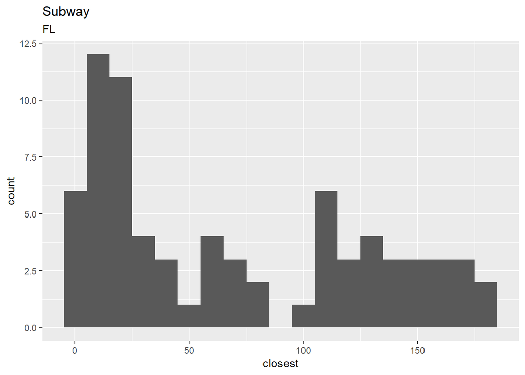

```r
ggplot(t_rest, aes(x=closest)) +geom_histogram(binwidth = 10)+ labs(title = data_s1$name, subtitle = data_s1$province)
```

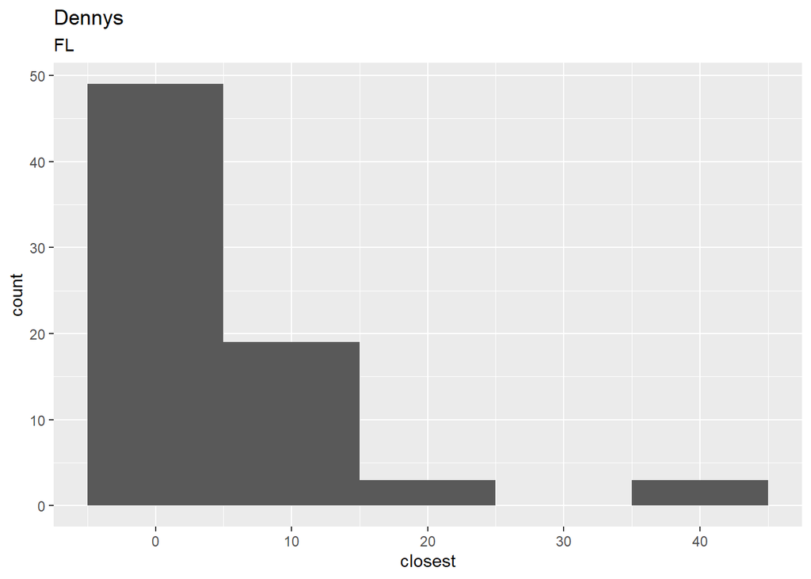

```r
ggplot(t_dennys, aes(x=closest)) +geom_histogram(binwidth = 10)+ labs(title = "Dennys", subtitle = data_s1$province)
```

Running the analysis again for another random number, we get the following:

```r
set.seed(546734334)
data_s1 <- FastFoodRestaurants[sample(1:nrow(FastFoodRestaurants), 1),]

t_rest<- restaurant(data_s1$province, data_s1$name)
t_dennys <- analyze(data_s1$province)
summary(t_rest)
```

```
##    address             closest
##  Length:237         Min.   :  0.016
##  Class :character   1st Qu.:  2.125
##  Mode  :character   Median :  6.650
##                     Mean   : 20.022
##                     3rd Qu.: 32.411
##                     Max.   :215.578
```

```r
summary(t_dennys)
```

```
##   address.y            closest
##  Length:237         Min.   :  0.016
##  Class :character   1st Qu.:  1.097
##  Mode  :character   Median :  5.028
##                     Mean   : 15.990
##                     3rd Qu.: 16.516
##                     Max.   :185.167
```

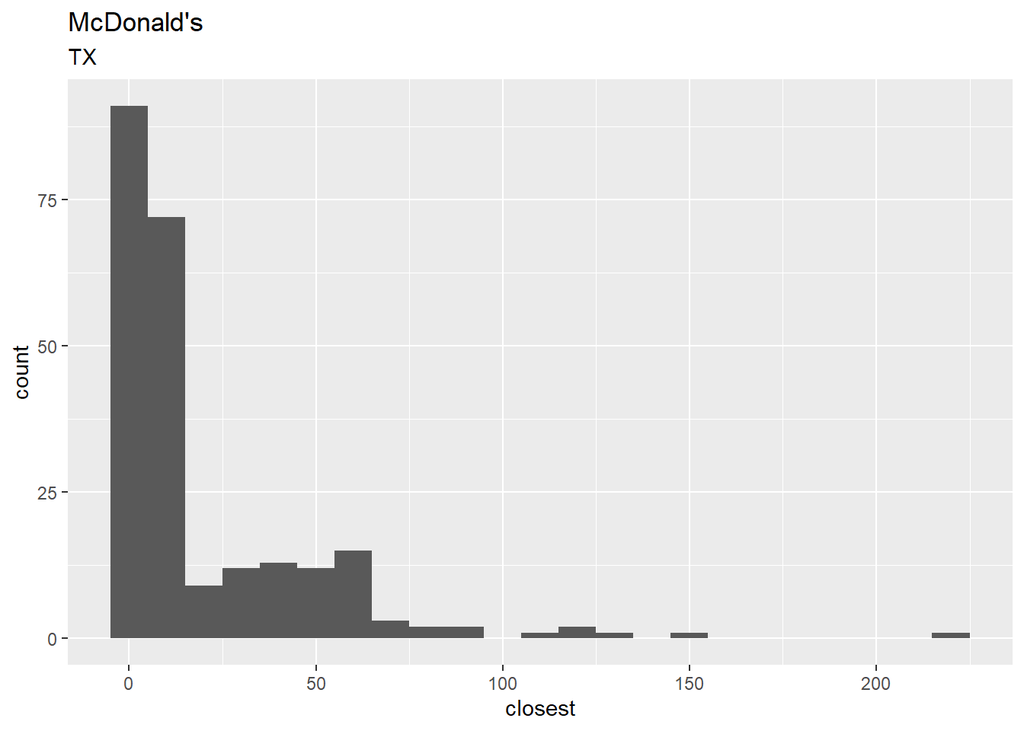

```r
ggplot(t_rest, aes(x=closest)) +geom_histogram(binwidth = 10)+ labs(title = data_s1$name, subtitle = data_s1$province)
```

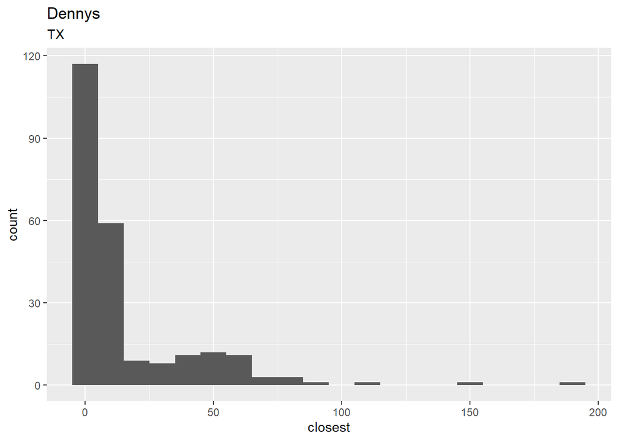

```r
ggplot(t_dennys, aes(x=closest)) +geom_histogram(binwidth = 10)+ labs(title = "Dennys", subtitle = data_s1$province)
```

Reflection: This is another good example of the the basics of everything we did in class. We were provided the data, so no searching was necessary. We then cleaned the data, and made it into something we found useful by joining the La Quinta and Denny’s data sets. We then created some visualizations and through these visualizations were able to say something about the proximity of La Quintas and Denny’s by comparing the proximity to other fast food restaurants.